# 텍스트분석 뉴스레터: 2023년 4월

sung won kang

2023 5 18

- 한국환경연구원 텍스트 수집 도구는 2023년 5월 23일까지 네이버 기사 데이터와 환경부 문헌 데이터를 제공한다. 아래 뉴스레터에서는 2023년 4월 30일을 기점으로 30일 이전까지 수집한 자료를 사용한다.

### A. Text 데이터

분석 대상 Text Data는 다음 두 종류의 문헌을 자료이다.

1. NAVER 환경 뉴스 : 2023년 4월 1일-2023년 4월 30일 NAVER 뉴스> ‘사회’ >‘환경’ 부문에 게시된 뉴스
2. 환경부 문건 : 2023년 4월 1일-2023년 4월 30일 환경부홈페이지에 게시된 환경부 보도자료 및 e-환경뉴스

’NAVER 환경 뉴스’는 환경정책의 수요자인 국민의 환경과 관련된 관심사를 전달하는 텍스트 자료이다. 그리고 ’환경부 문건’은 환경정책의 공급자인 환경부의 관심사를 전달하는 텍스트 자료이다. 이 두 자료의 키워드를 비교하여 환경정책 공급자의 관심사가 환경정책 수요자의 관심사에 조응하는지 여부를 점검한다.

### B. 키워드 빈도분석

한국환경연구원의 환경 빅데이터 플랫폼에서는 키워드를 단순빈도수 및 TF_IDF 값에 따라 추출한다. 키워드 추출 전단계로 파이선’konlpy’패키지를 활용한 형태소 분석 및 품사 태깅을 수행하고, 불용어(stopwords)를 제거한다. 2023년 4월 1일 - 4월 30일 게시 NAVER 환경뉴스 및 환경부 문건에서 단순빈도수가 높은 20개의 키워드를 추출한 결과는 아래 그림과 같다.

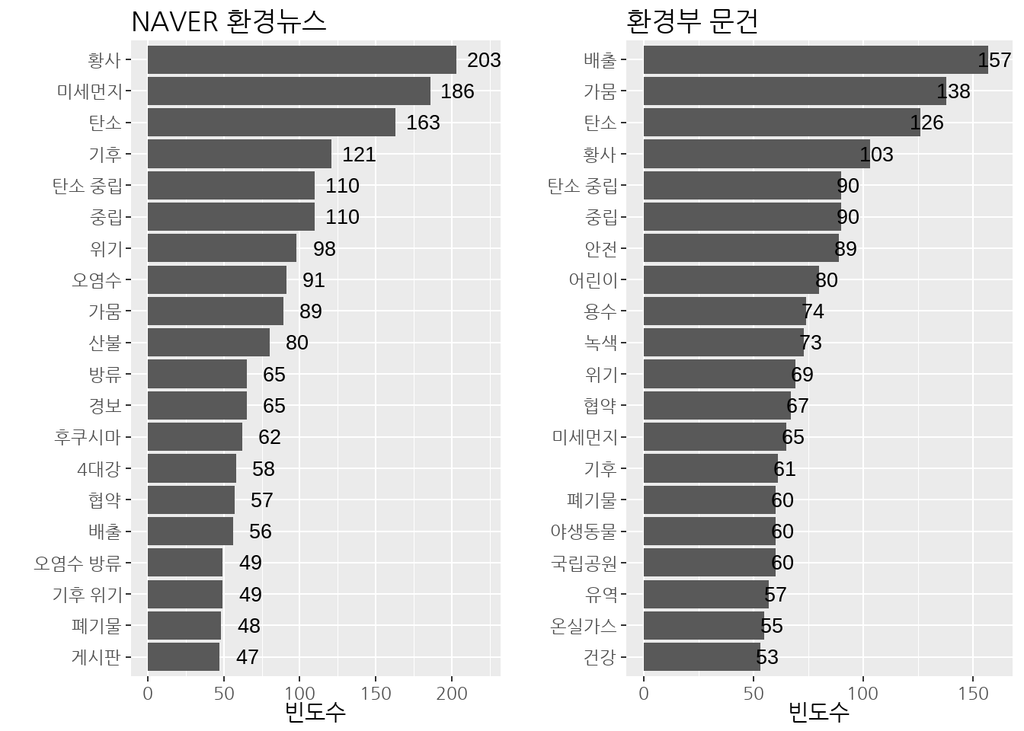

눈에 띄는 차이는 두 가지로 정리할 수 있다.

- 첫째, 네이버 환경뉴스에는 빈도수가 높은 상위 20개 키워드 중 ‘오염수’,‘후쿠시마’,‘오염수 방류’,‘방류’ 등 후쿠시마 제1원자력발전소 오염수 방류와 관련된 키워드 및 ’산불’이 발견되었지만 환경부 문건의 빈도수 상위 20개 키워드에는 이에 상응하는 키워드가 발견되지 않았다.
- 둘째, 환경부 문건의 빈도수 상위 20개 키워드 중에는 ‘안전’,‘어린이’,‘건강’ 등 환경보건 관련 키워드 및 ‘국립공원’,‘야생동물’ 등 자연환경 관련 키워드, 그리고 ‘용수’,‘녹색’ 등의 키워드가 포함되지만 네이버 환경뉴스에서는 이에 상응하는 키워드가 발견되지 않았다.

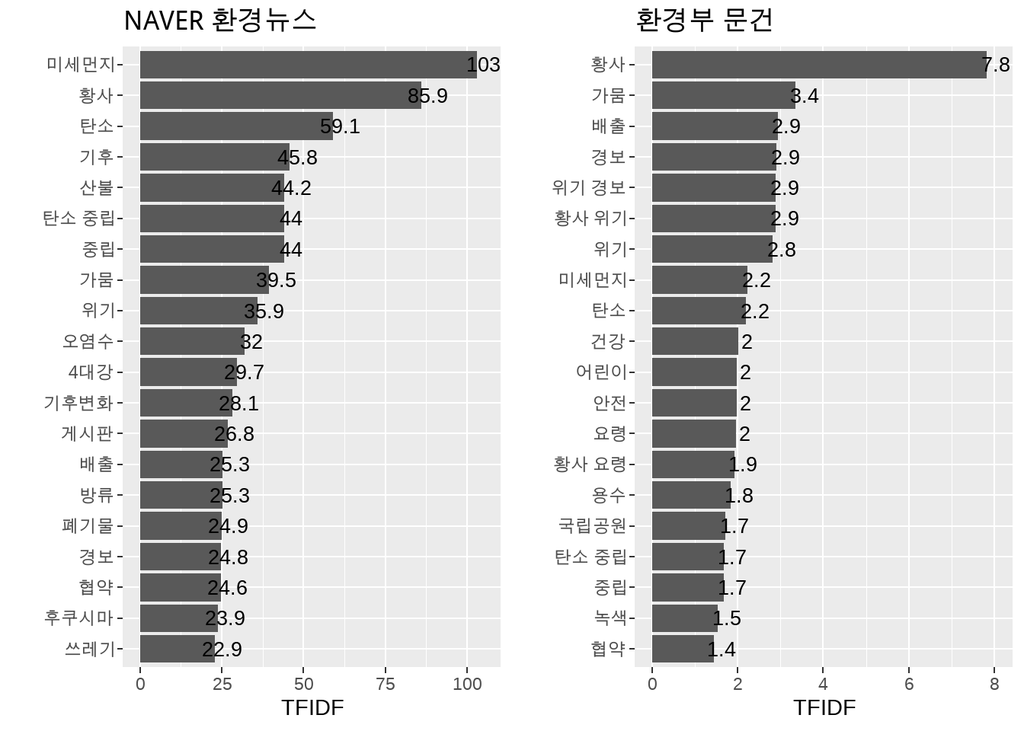

### C.키워드 관련 뉴스

네이버 환경뉴스 키워드와 환경부 문건 키워드간의 차이의 원인을 파악하기 위해서 두 문헌에서 단순빈도가 가장 높은 10개 키워드 중 서로 상이한 키워드가 포함된 문헌의 제목들을 비교하였다.

- 네이버 환경뉴스에서 단순빈도가 높은 10개 키워드 중 환경부 문건의 단순빈도가 높은 20개 키워드에 포함되지 않은 키워드는 [오염수, 산불]이다.
- 환경부 문헌에서 단순빈도가 높은 10개 키워드 중 네이버 환경뉴스에서 단순빈도가 높은 20개 키워드에 포함되지 않은 키워드는 [안전, 어린이, 용수, 녹색]이다.
1. ’오염수’를 제목에 포함하는 기사들은 후쿠시마 제1원자력발전소 오염수 방류와 관련된 기사로 파악되었다. 후쿠시마 원자력 발전소 오염수 방류는 환경부의 정책과 직접 관련되지는 않는 기사들이다.

| Title |
| --- |
| 가뭄 대책으로 ’오염수’도 쓰겠다는 정부 |
| 한총리 “오염수, 필요시 독자검사할 수 있도록 日과 협의” |
| 일본국민 52% “후쿠시마 오염수 방류 국민 이해 못 얻어” |
| 후쿠시마 오염수 해양방류 반대 |
| ‘후쿠시마 오염수 방류 안돼!’ |
| 후쿠시마 오염수 방류 저지의 목소리 |
| 후쿠시마 오염수 방류 저지 촉구하는 YWCA 회원들 |
| 대통령집무실 앞 후쿠시마 오염수 방류 반대 목소리 |
| YWCA ‘후쿠시마 오염수 방류 안 돼’ |
| 한국YWCA, 후쿠시마 오염수 방류 저지 긴급행동 |

2. ’산불’을 제목에 포함하는 기사들은 4월 2일 발생한 인왕산 산불 및 4월 2일 개최된 유한킴벌리가 주관한 동해 산불지역 나무심기 행사와 관련된 기사로 파악되었다.

| Title |
| --- |
| 인왕산 산불로 축구장 19개 면적 산림 소실…5시간째 진화 중(종합) |
| 동해 산불지역에서 나무 심는 신혼부부들 |
| 인왕산 산불 축구장 19개 면적 산림 소실…대응 1단계 하향(종합2보) |
| [속보]서울 인왕산 산불, 소방 대응 2단계→1단계 하향 |
| 유한킴벌리, 동해 산불 지역서 ‘신혼부부 나무 심기’ 행사 개최 |
| 건조한 데다 강풍까지, 산불 다발하는 이유···4일 비에 해소 전망 |
| 올해 서울에 10㎜ 넘는 비 딱 한번…가뭄에 강풍까지 ‘산불비상’(종합) |
| 서울 인왕산 산불 진화율 70~80％…3시간째 진화 중 |
| 서울 인왕산 산불 발생…8부 능선서 북쪽으로 번져 |
| 유한킴벌리, 동해 산불 피해지 복원위한 나무심기 행사 가져 |

환경부 문헌에서 가장 빈도가 높은 10개 키워드 중 네이버 뉴스에서 가장 빈도가 높은 키워드 20개에 포함되지 않은 키워드는 “안전”, “어린이”, “용수”,“녹색”이다. 2023년 4월 1일부터 4월 30일까지 게시된 환경부 문헌 중 이들 키워드를 제목에 포함하는 환경부 문헌은 다음과 같다.

1. ’안전’을 제목에 포함하는 문헌들은 어린이 환경안전 정책 및 화학사고 안전 정책 관련 문헌으로 파악되었다.

| Title |
| --- |
| 화학안전정책, 국민의 목소리 반영한다 |
| 건강하고 안전하게 놀자…어린이 환경안전 전시회 개최 |
| 어린이 안전을 위한 교통안전, 제품안전 등 6개 분야 추진계획 발표 |
| 화학사고 취약 사업장 400곳 집중안전점검 |

2. ’용수’를 제목에 포함하는 문헌들은 용수공급과 관련된 문헌으로 대체 수자원 개발 관련 문헌 1건 및 강우로 인한 용수공급 여력 관련 문헌 1건이 있었다.

| Title |
| --- |
| 물 공급체계 조정, 대체 수자원 개발로 하루 61만톤 용수 추가 확보 |
| 남부지방 반가운 봄비, 댐 용수공급 한숨 돌려 |

3. ‘녹색’ 관련 문헌은 녹색투자, 녹색경제, 녹색산업 관련 문헌이 1건씩 존재하였다. 이는 모두 기후변화 대응을 경제적인 기회로 활용하는 정책과 관련된 문헌이었다.

| Title |
| --- |
| 중소기업에도 녹색투자 길 열린다 |
| ’2050 탄소중립 달성과 녹색성장 실현’을 위한 국가 전략 및 제1차 국가… |
| 환경기업의 의견에서 녹색산업의 길을 묻다 |

### D. 정리

2023년 4월 1일-2023년 4월 30일 게시된 네이버 환경뉴스와 환경부 문헌을 비교한 결과를 요약하면 다음과 같다.

1. 네이버 기사로부터 후쿠시마 원자력발전소의 오염수 방류 및 산불에 대한 국민들의 관심이 많은데 이와 관련된 환경부 문건의 비중은 낮은 것으로 파악되었다.
2. 환경부 문헌으로부터 이 당시 환경부는 환경안전 증진, 온실가스 감축 정책에 기반한 경제적 기회 활용, 가뭄 대비 용수 공급량 확보 정책을 추진하였음을 알 수 있다. 이 중 온실가스 감축정책에 기반한 경제적 기회 활용 정책은 NAVER 뉴스에서 빈도가 높았던 ‘기후’ 관련 관심에 조응하는 정책이라고 할 수 있다. 그러나 이외의 정책은 NAVER 뉴스의 관심을 얻지 못하였다.